# item Recommender

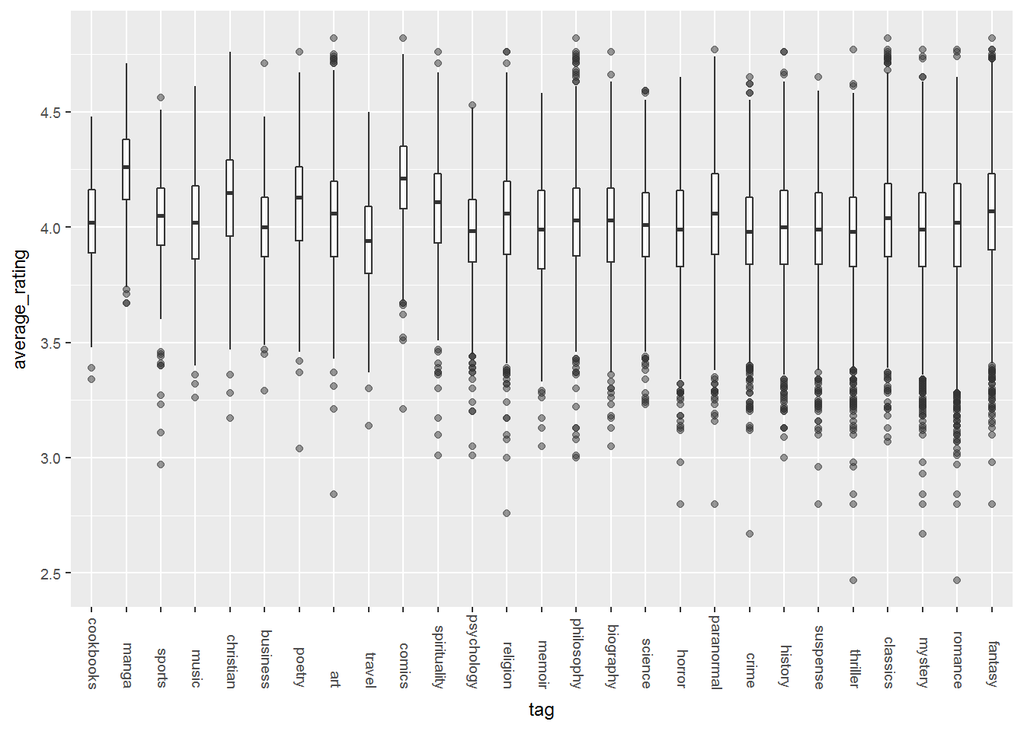

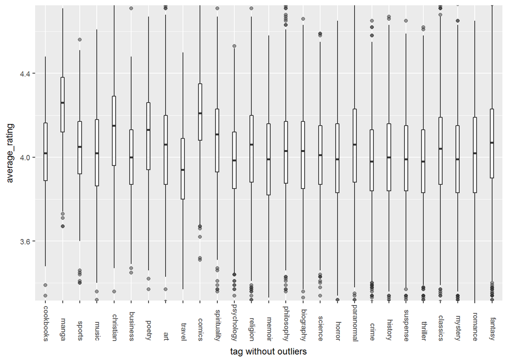

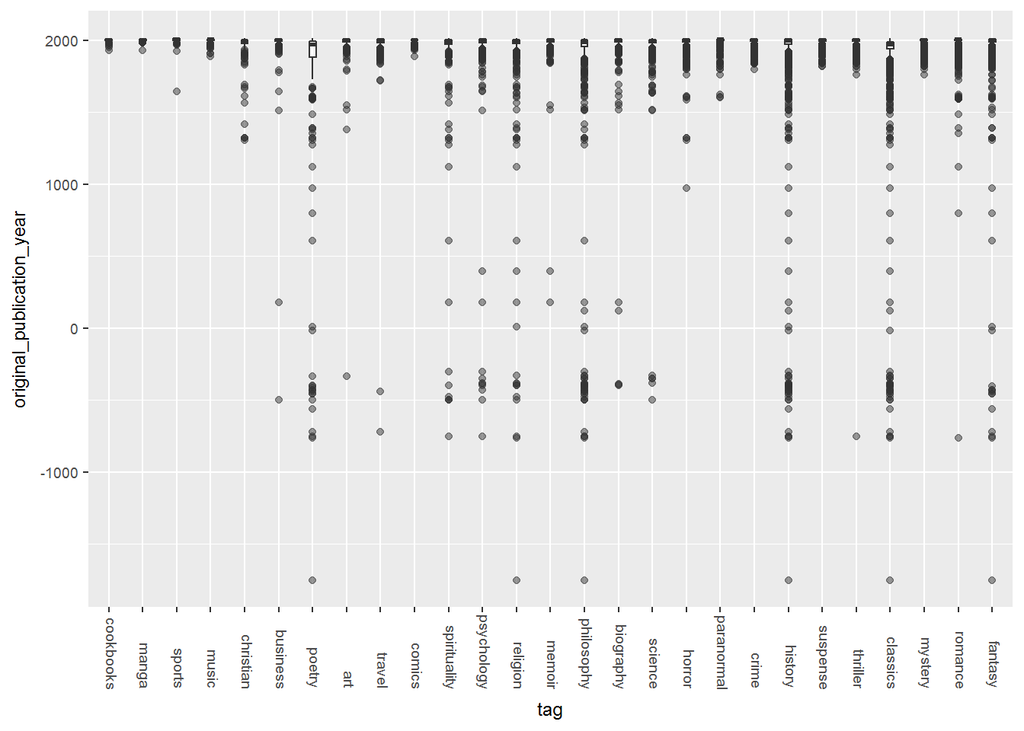

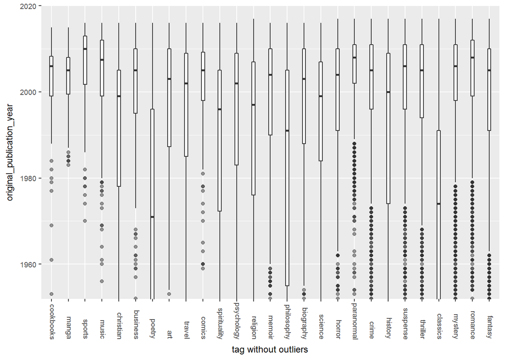

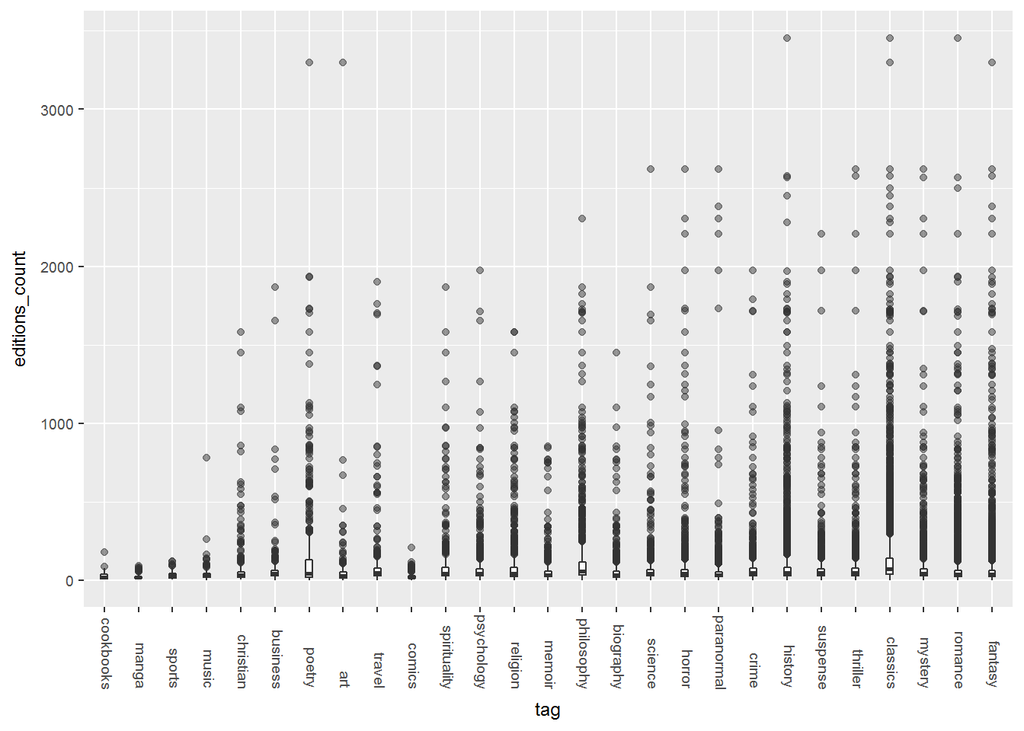

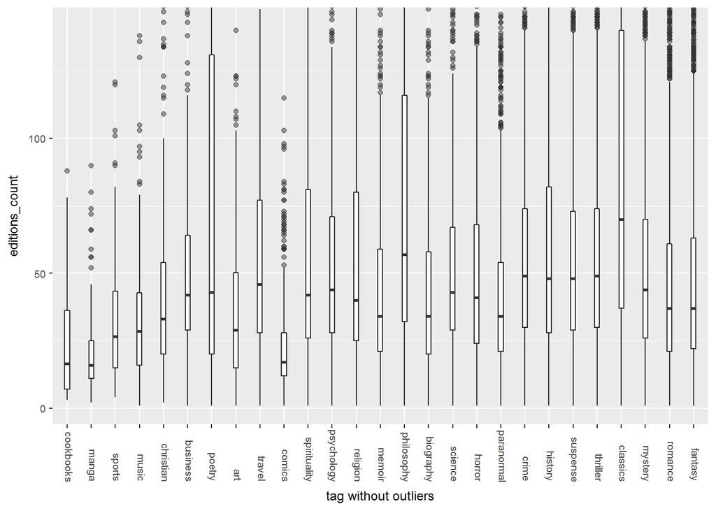

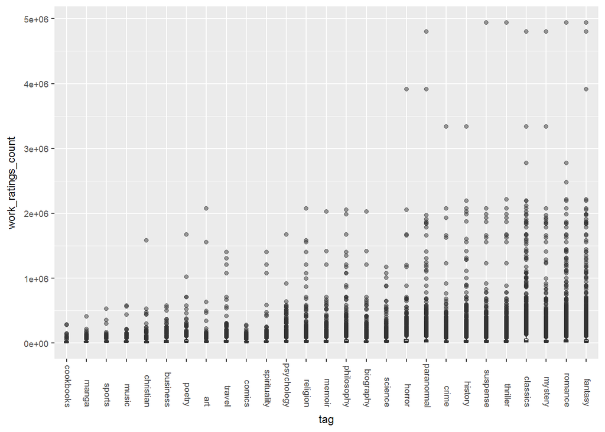

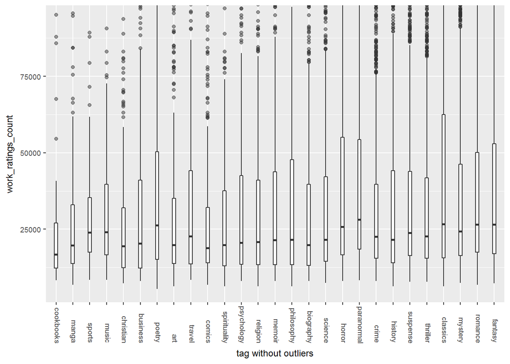

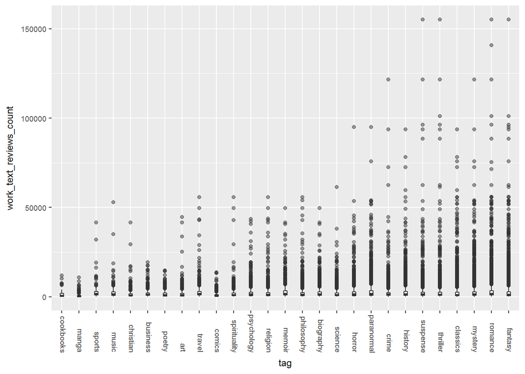

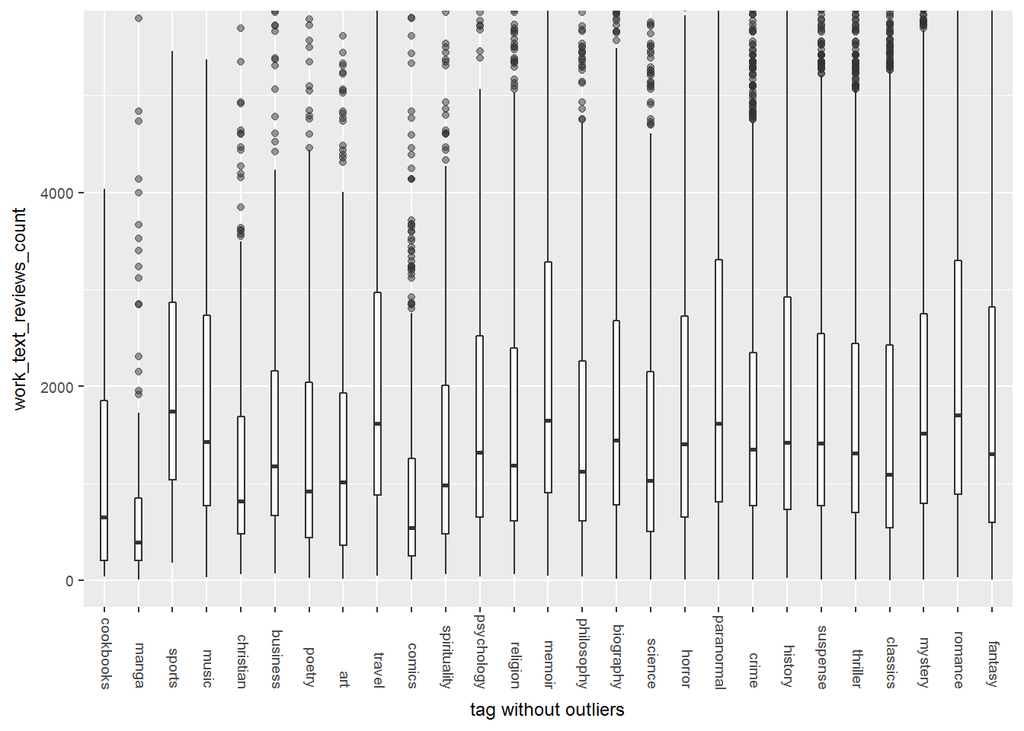

```r
itemsntags<-merge(books,item_tags[tag_id %in% available_tags],by="goodreads_book_id",all.x=T)
itemsntags<-merge(itemsntags,tmp,by="tag_id")


for(col_name in cols_tosee){
  print(ggplot(itemsntags, aes(y=get(col_name), x=reorder(as.factor(tag_name),percentage))) +
    geom_boxplot(stat="boxplot", position="dodge", alpha=0.5, width=0.2) + theme_grey() + theme(text=element_text(family="sans", face="plain", color="#000000", size=9, hjust=0.5, vjust=0.5)) + xlab("tag") + ylab(col_name)+theme(axis.text.x=element_text(size=7, angle=270,hjust=0.95,vjust=0.2)))

  fn<-fivenum(itemsntags[[col_name]], na.rm = TRUE)
  iqr<-1.5 * (fn[4]-fn[2]);
  print(ggplot(itemsntags, aes(y=get(col_name), x=reorder(as.factor(tag_name),percentage))) +
    geom_boxplot(stat="boxplot", position="dodge", alpha=0.5, width=0.2) + theme_grey() + theme(text=element_text(family="sans", face="plain", color="#000000", size=9, hjust=0.5, vjust=0.5)) + xlab("tag without outliers") + ylab(col_name)+theme(axis.text.x=element_text(size=7, angle=270,hjust=0.95,vjust=0.2)) +
    coord_cartesian(ylim=c( min(fn[4]+iqr,fn[5]),max(fn[2]-iqr,fn[1]) )) )
}
```

#### Different languages

You might have seen in the `item_content.csv` that there is language information on the items. This is interesting because most sites are english speaking. However, the dataset contains some items in different languages. The reason is that typically there are multiple editions of a item (both in the same language and in different languages). For this dataset it seems that the most popular edition was included, which for some items is their original language.

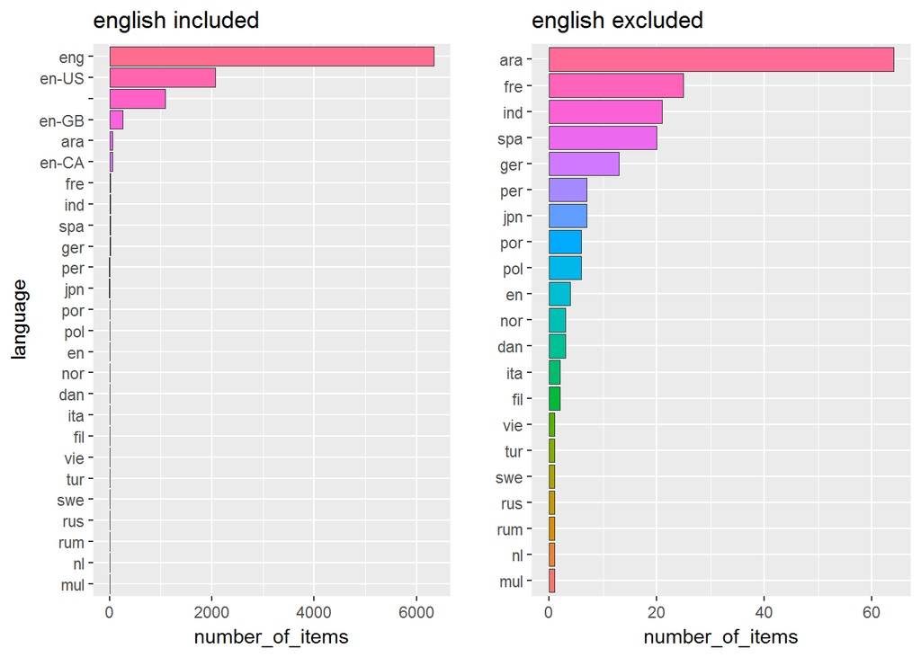

```r
p1 <- books %>%
  mutate(language = factor(language_code)) %>%
  group_by(language) %>%
  summarize(number_of_items = n()) %>%
  arrange(-number_of_items) %>%
  ggplot(aes(reorder(language, number_of_items), number_of_items, fill = reorder(language, number_of_items))) +
  geom_bar(stat = "identity", color = "grey20", size = 0.35) + coord_flip() +
  labs(x = "language", title = "english included") + guides(fill = FALSE)

p2 <- books %>%
  mutate(language = factor(language_code)) %>%
  filter(!language %in% c("en-US", "en-GB", "eng", "en-CA", "")) %>%
  group_by(language) %>%
  summarize(number_of_items = n()) %>%
  arrange(-number_of_items) %>%
  ggplot(aes(reorder(language, number_of_items), number_of_items, fill = reorder(language, number_of_items))) +
  geom_bar(stat = "identity", color = "grey20", size = 0.35) + coord_flip() +
  labs(x = "", title = "english excluded") + guides(fill = FALSE)

grid.arrange(p1,p2, ncol=2)
```

Group items by above categorical varieble then plot every interesting column. Maybe I just like making plots.

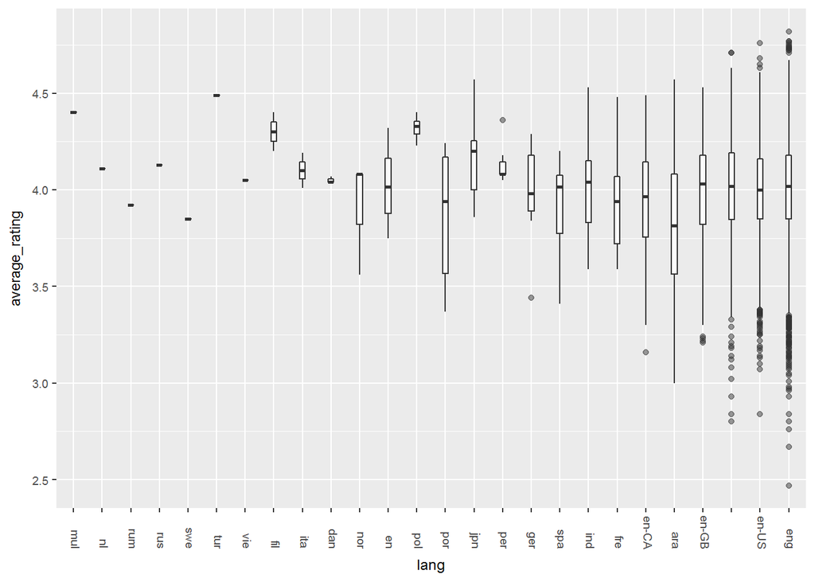

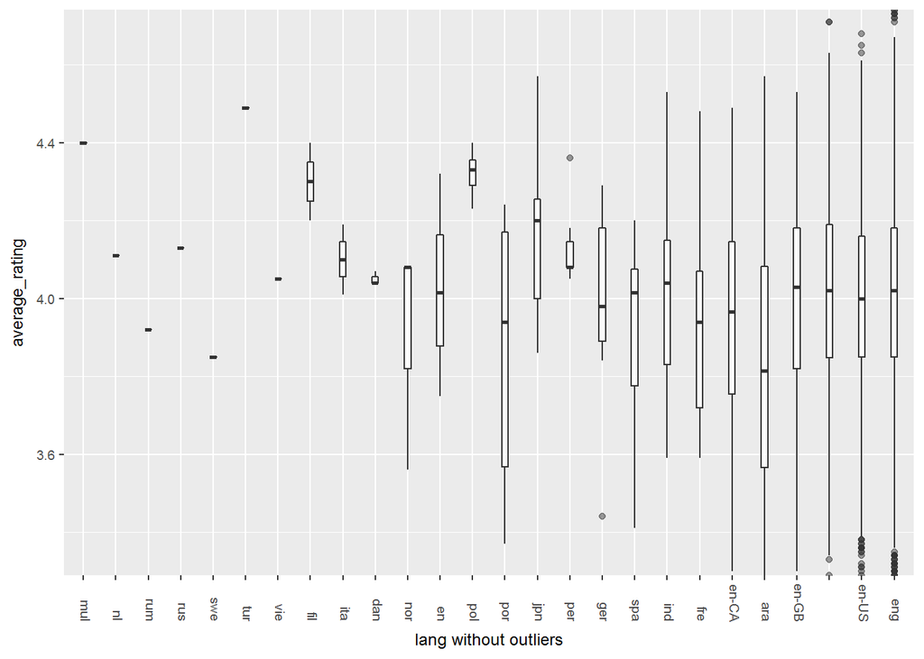

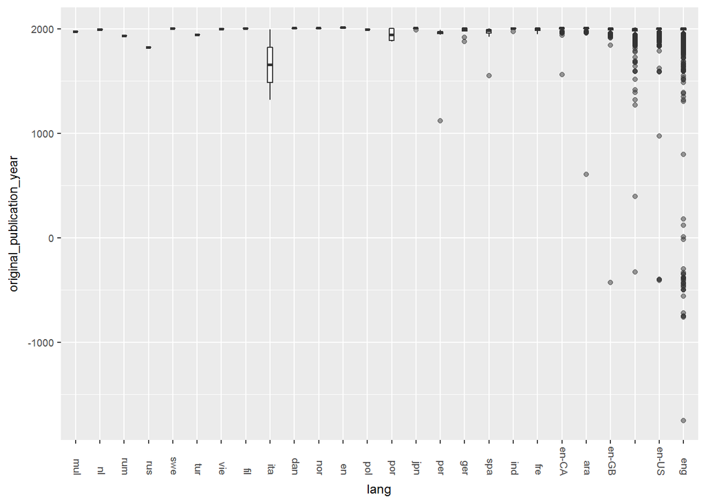

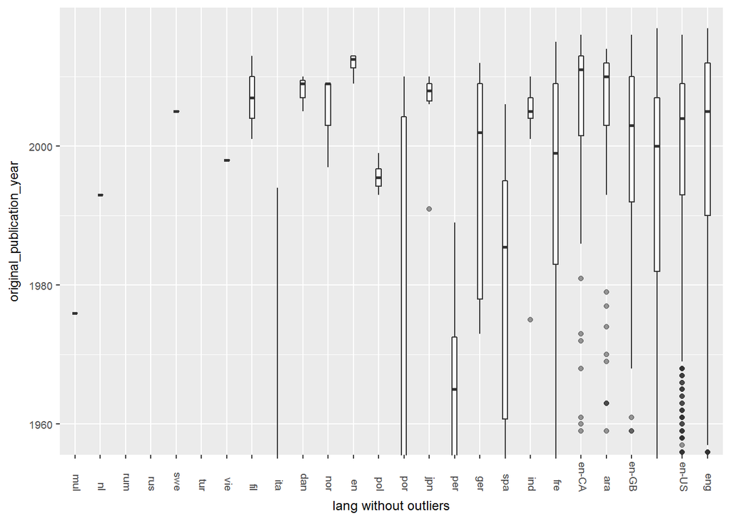

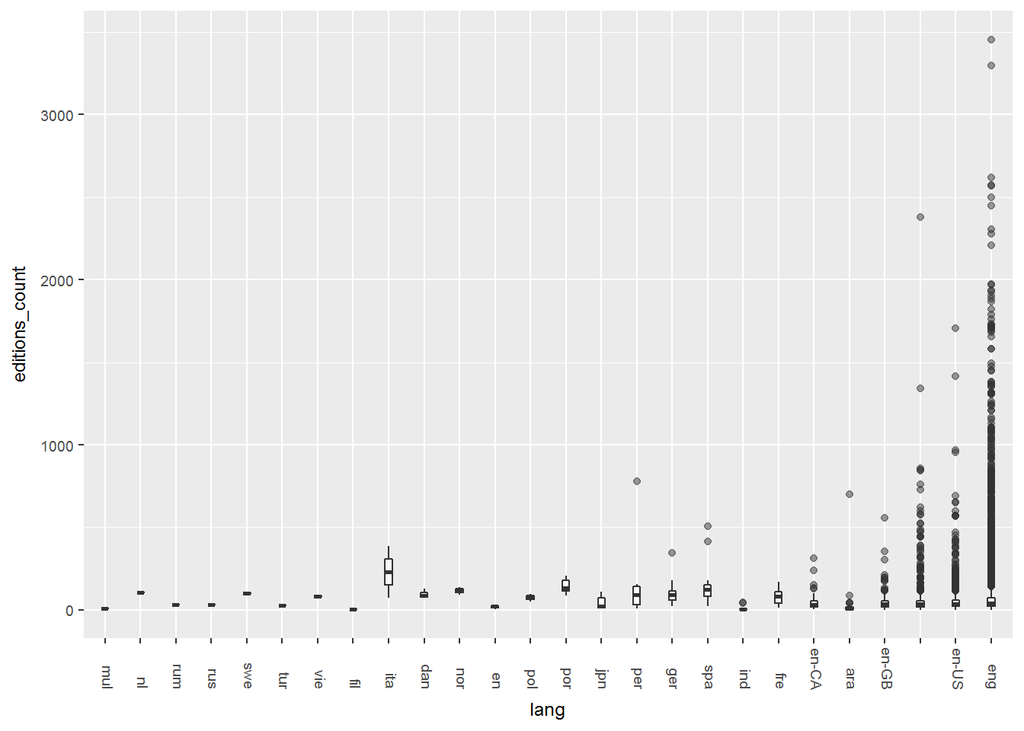

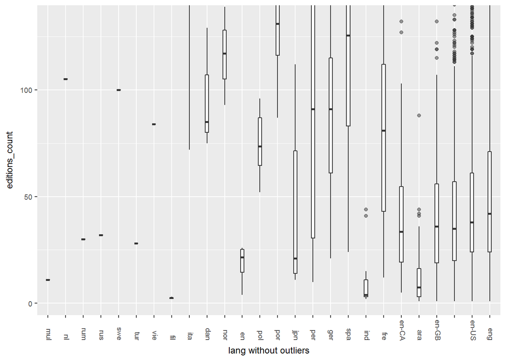

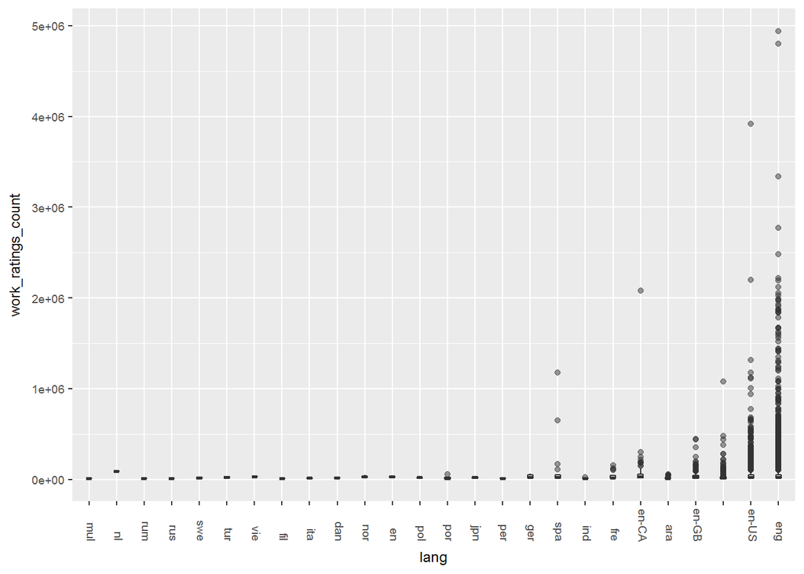

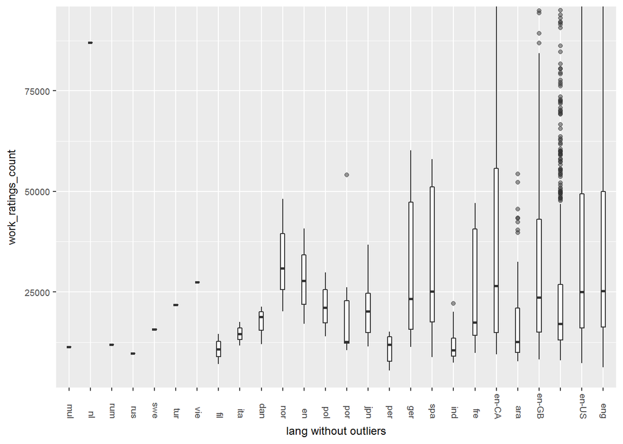

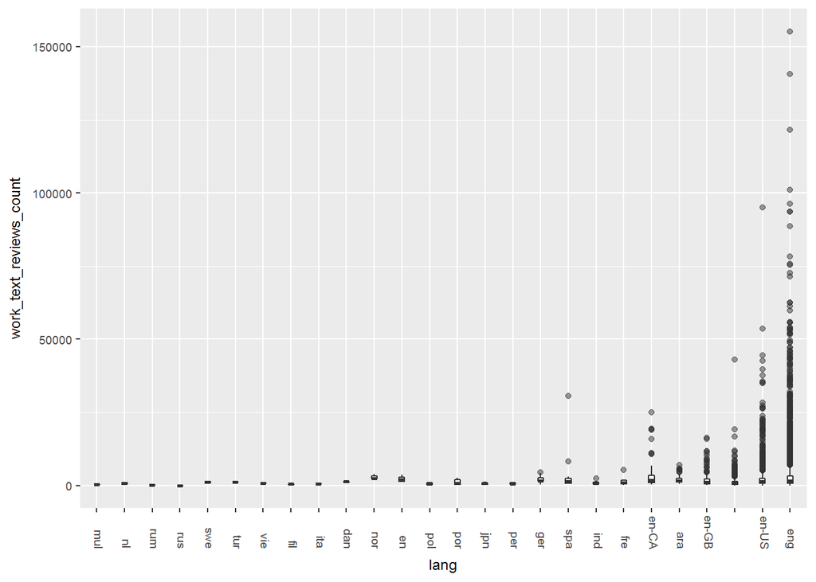

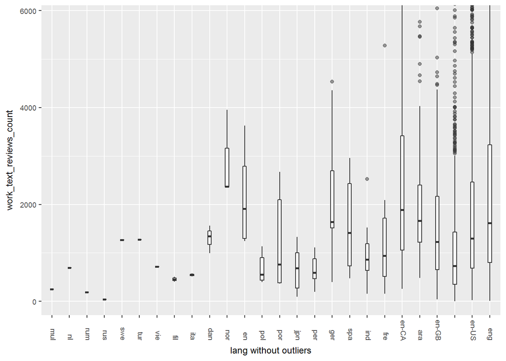

```r
books[, NLv := .N, .(language_code)]

for(col_name in cols_tosee){
print(ggplot(books, aes(y=get(col_name), x=reorder(as.factor(language_code),NLv))) +
    geom_boxplot(stat="boxplot", position="dodge", alpha=0.5, width=0.2) + theme_grey() + theme(text=element_text(family="sans", face="plain", color="#000000", size=9, hjust=0.5, vjust=0.5)) + xlab("lang") + ylab(col_name)+theme(axis.text.x=element_text(size=7, angle=270,hjust=0.95,vjust=0.2)))

  fn<-fivenum(books[[col_name]], na.rm = TRUE)
  iqr<-1.5 * (fn[4]-fn[2]);
print(ggplot(books, aes(y=get(col_name), x=reorder(as.factor(language_code),NLv))) +
    geom_boxplot(stat="boxplot", position="dodge", alpha=0.5, width=0.2) + theme_grey() + theme(text=element_text(family="sans", face="plain", color="#000000", size=9, hjust=0.5, vjust=0.5)) + xlab("lang without outliers") + ylab(col_name)+theme(axis.text.x=element_text(size=7, angle=270,hjust=0.95,vjust=0.2)) +
    coord_cartesian(ylim=c( min(fn[4]+iqr,fn[5]),max(fn[2]-iqr,fn[1]) )) )
}
```

```r
#and crosstab language code
rm(itemsntags)
```

And finaly cross tabulation of the above 2 categorical variebles.

```r
itemsntags<-merge(books,item_tags[tag_id %in% available_tags],by="goodreads_book_id",all.x=T)
itemsntags<-merge(itemsntags,tmp,by="tag_id")
itemsntags[, NL := .N, .(language_code)]
itemsntags[, NT := .N, .(tag_name)]
itemsntags[, NLT := .N, .(language_code,tag_name)]
itemsntags[, NLTP := NLT/(NT*NL)]
.Table <- xtabs(~language_code+tag_name, data=itemsntags)
  cat("\nFrequency table:\n")
```

```
##
## Frequency table:
```

```r
  print(.Table)
```

```
##              tag_name
## language_code  art biography business christian classics comics cookbooks
##                 60       167       81        88      365     33        29
##         ara      1         4        0         0        7      2         0
##         dan      0         0        0         0        0      0         0
##         en       1         0        0         0        0      0         0
##         en-CA    3         9        2         2       12      1         0
##         en-GB    4        32       10         3       60      9         3
##         en-US   93       265       95       104      471     53        22
##         eng    268       616      188       159     1819    358        38
##         fil      0         0        0         0        0      0         0
##         fre      3         4        0         0       11      5         0
##         ger      1         1        0         0        5      1         0
##         ind      1         6        0         0        2      3         0
##         ita      0         0        0         1        2      0         0
##         jpn      0         0        0         0        1      4         0
##         mul      1         0        0         0        1      0         0
##         nl       0         0        0         0        0      0         0
##         nor      0         1        0         0        1      0         0
##         per      0         1        0         0        4      0         0
##         pol      0         0        0         0        1      0         0
##         por      0         1        0         0        5      0         0
##         rum      0         1        0         0        1      0         0
##         rus      0         0        0         0        1      0         0
##         spa      0         1        0         0       15      0         0
##         swe      0         0        0         0        0      0         0
##         tur      0         0        0         0        1      0         0
##         vie      0         0        1         0        0      0         0
##              tag_name
## language_code crime fantasy history horror manga memoir music mystery
##                 172     350     244    115    15    142    30     286
##         ara       5       8      20      7     0      1     0       7
##         dan       3       0       0      0     0      0     0       3
##         en        0       0       1      0     0      0     0       1
##         en-CA    11      27      14      9     1      7     0      23
##         en-GB    55     106      48     36     5     28    12      98
##         en-US   433     942     471    301    30    213    52     794
##         eng    1387    2782    1321    883   136    503   130    2439
##         fil       0       0       0      0     0      0     0       0
##         fre       7      10       5      6     2      3     0       9
```

[output cut: 57 more lines]

```
##         ind         2            2      0        0        0      3
##         ita         0            0      0        0        0      0
##         jpn         0            0      0        0        2      0
##         mul         0            1      0        0        0      0
##         nl          0            0      0        1        1      0
##         nor         0            0      0        2        2      0
##         per         0            1      0        0        0      0
##         pol         0            0      0        0        0      0
##         por         0            3      0        0        0      1
##         rum         0            0      0        0        0      0
##         rus         0            0      0        0        0      0
##         spa         3            1      0        7        7      1
##         swe         0            0      0        1        1      0
##         tur         0            0      0        0        0      0
##         vie         0            0      0        0        0      0
```

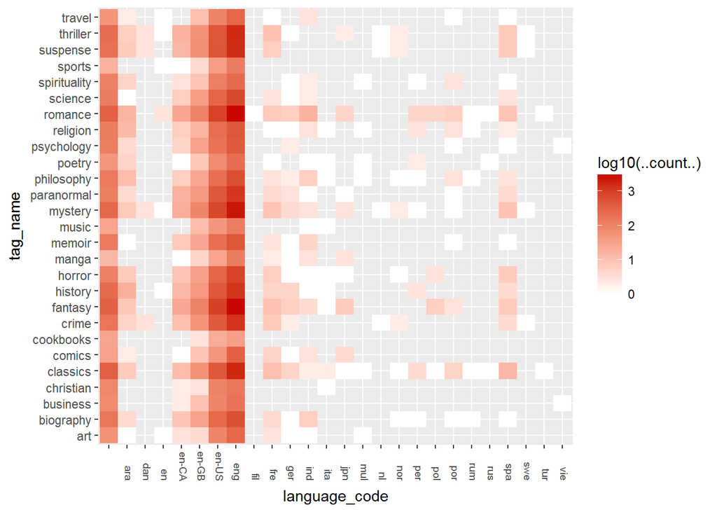

```r
  ggplot() +
 geom_bin2d(aes(x = language_code,y = tag_name,fill = log10(..count..)),data=itemsntags,drop = FALSE) +
scale_fill_gradient(guide = guide_colourbar(),low = '#ffffff',high = '#c90700') +theme(axis.text.x=element_text(size=7, angle=270,hjust=0.95,vjust=0.2))
```

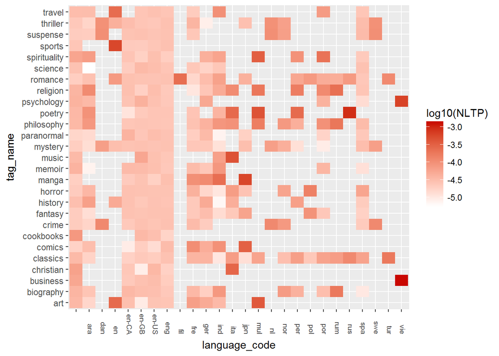

```r
  ggplot() +
 geom_bin2d(aes(x = language_code,y = tag_name,fill = log10(NLTP)),data=itemsntags,drop = FALSE) +
scale_fill_gradient(guide = guide_colourbar(),low = '#ffffff',high = '#c90700') +theme(axis.text.x=element_text(size=7, angle=270,hjust=0.95,vjust=0.2))
```

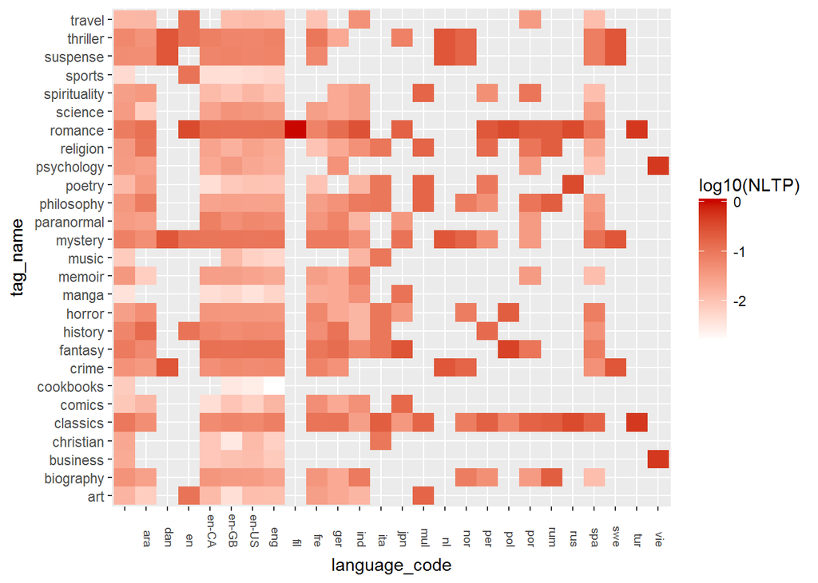

```r
  itemsntags[, NLTP := NLT/(NL)]
    ggplot() +
 geom_bin2d(aes(x = language_code,y = tag_name,fill = log10(NLTP)),data=itemsntags,drop = FALSE) +
scale_fill_gradient(guide = guide_colourbar(),low = '#ffffff',high = '#c90700') +theme(axis.text.x=element_text(size=7, angle=270,hjust=0.95,vjust=0.2))
```

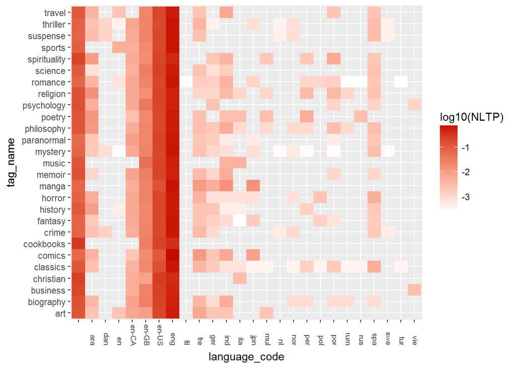

```r
  itemsntags[, NLTP := NLT/(NT)]
    ggplot() +
 geom_bin2d(aes(x = language_code,y = tag_name,fill = log10(NLTP)),data=itemsntags,drop = FALSE) +
scale_fill_gradient(guide = guide_colourbar(),low = '#ffffff',high = '#c90700') +theme(axis.text.x=element_text(size=7, angle=270,hjust=0.95,vjust=0.2))
```

```r
rm(itemsntags)#MUST SORT!!
```

Crosstabulation and graphs. First xtab of log10 of counts. 3rd and 4th are percentages of column and row. 2nd cells are calculated as cell count / (row count * column count). All log 10 so a few spots don’t outshine evrything else. Goal is to see unexpected high counts. For example, using books, 4th graph implies that spirituality comics and manga are popular in India. 3rd graph shows that all forms of english like tags almost in the same proportion.

#### What influences a item’s rating?

Next, we can see, whether we can find any associations of features with a item’s rating. For a quick look, let’s first plot the correlation matrix between the items average_rating and some variables. In summary, we see only small correlations between the features and the average rating (last row), indicating that there are no strong relationships between the rating a item receives and meta-variables (like rating counts etc.). This means that the rating depends more strongly on other features (e.g. the quality of the items itself).

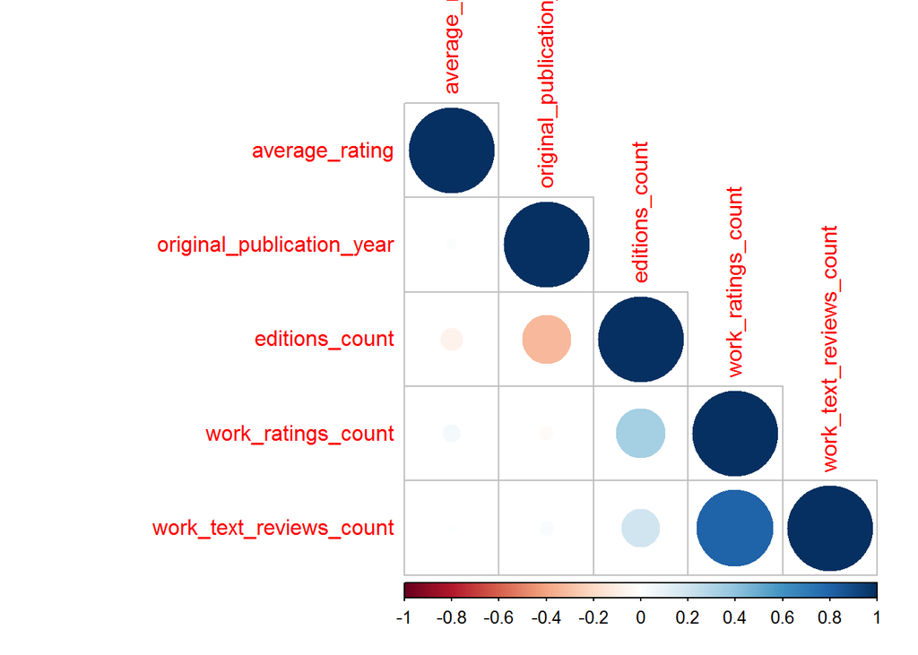

```r
tmp <- books %>%
  select(one_of( cols_tosee)) %>%
  as.matrix()

corrplot(cor(tmp, use = 'pairwise.complete.obs'), type = "lower")
```

#### Is there a relationship between the number of ratings and the average rating?

Theoretically, it might be that the popularity of a item (in terms of the number of ratings it receives) is associated with the average rating it receives, such that once a item is becoming popular it gets better ratings. However, our data shows that this is true only to a very small extent. The correlation between these variables is only 0.045.

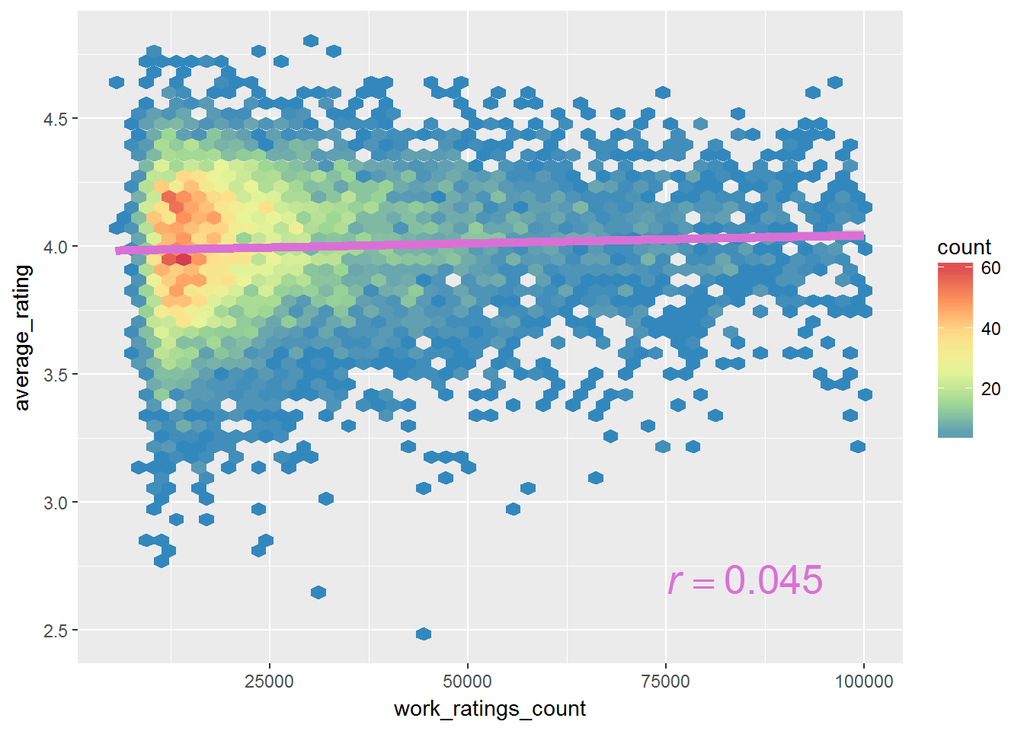

```r
get_cor <- function(df){
    m <- cor(df$x,df$y, use="pairwise.complete.obs");
    eq <- substitute(italic(r) == cor, list(cor = format(m, digits = 2)))
    as.character(as.expression(eq));
}

books %>%
  filter(work_ratings_count < 1e+5) %>%
  ggplot(aes(work_ratings_count, average_rating)) + stat_bin_hex(bins = 50) + scale_fill_distiller(palette = "Spectral") +
  stat_smooth(method = "lm", color = "orchid", size = 2) +
  annotate("text", x = 85000, y = 2.7, label = get_cor(data.frame(x = books$work_ratings_count, y = books$average_rating)), parse = TRUE, color = "orchid", size = 7)
```

#### Multiple editions of each item

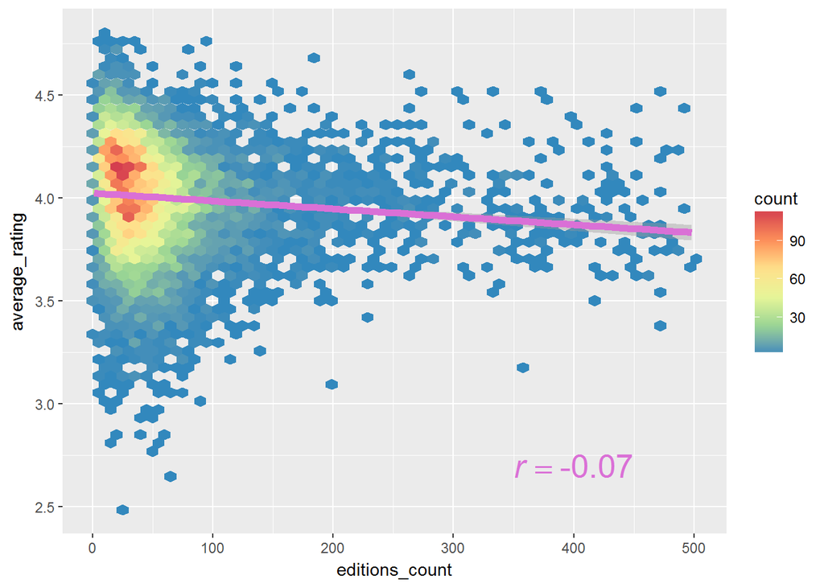

```r
books %>% filter(editions_count <= 500) %>% ggplot(aes(editions_count, average_rating)) + stat_bin_hex(bins = 50) + scale_fill_distiller(palette = "Spectral") +
  stat_smooth(method = "lm", color = "orchid", size = 2) +
  annotate("text", x = 400, y = 2.7, label = get_cor(data.frame(x = books$editions_count, y = books$average_rating)), parse = TRUE, color = "orchid", size = 7)
```

#### Do frequent raters rate differently?

It is possible, that users that rate more items (frequent raters) rate items differently from less frequent raters. The figure below explores this possibility. It seems like frequent raters tend to give lower ratings to items, maybe they are/become more critical the more they read and rate. That’s interesting.

Look at the distribution of ratings of users with few ratings at about line 220.

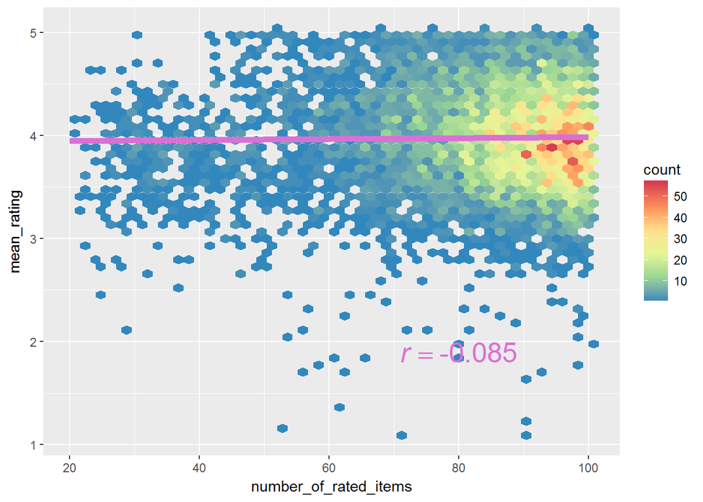

```r
tmp <- ratings %>%
  group_by(user_id) %>%
  summarize(mean_rating = mean(rating), number_of_rated_items = n())

tmp %>% filter(number_of_rated_items <= 100) %>%
  ggplot(aes(number_of_rated_items, mean_rating)) + stat_bin_hex(bins = 50) + scale_fill_distiller(palette = "Spectral") + stat_smooth(method = "lm", color = "orchid", size = 2, se = FALSE) +
  annotate("text", x = 80, y = 1.9, label = get_cor(data.frame(x = tmp$number_of_rated_items, y = tmp$mean_rating)), color = "orchid", size = 7, parse = TRUE)
```

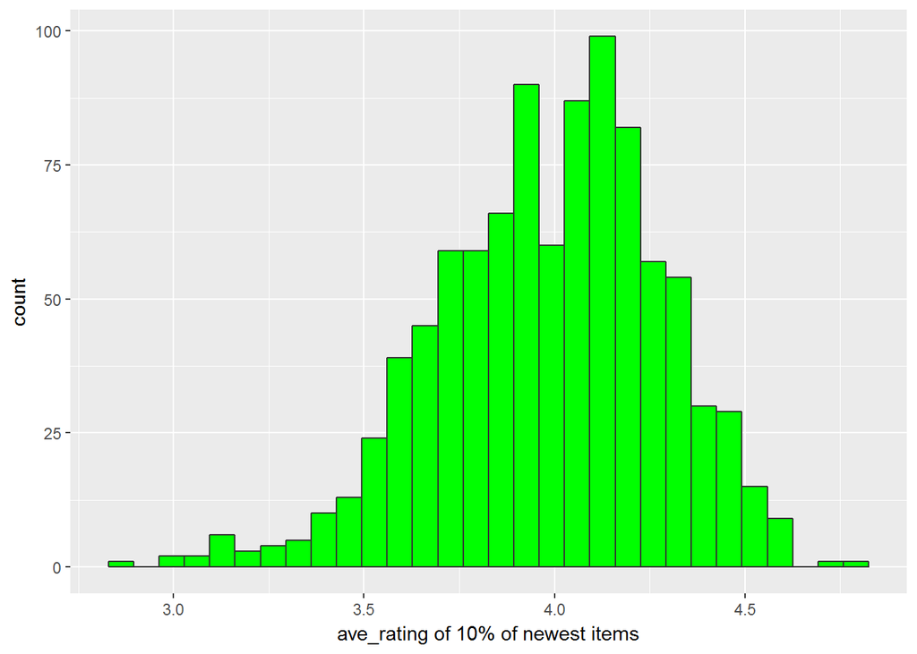

```r
books %>%
  filter(original_publication_year>
                 quantile(original_publication_year,probs=.9,na.rm=T) )%>%
  ggplot(aes(average_rating)) + geom_histogram(fill = "green", color = "grey20")+
  xlab("ave_rating of 10% of newest items")
```

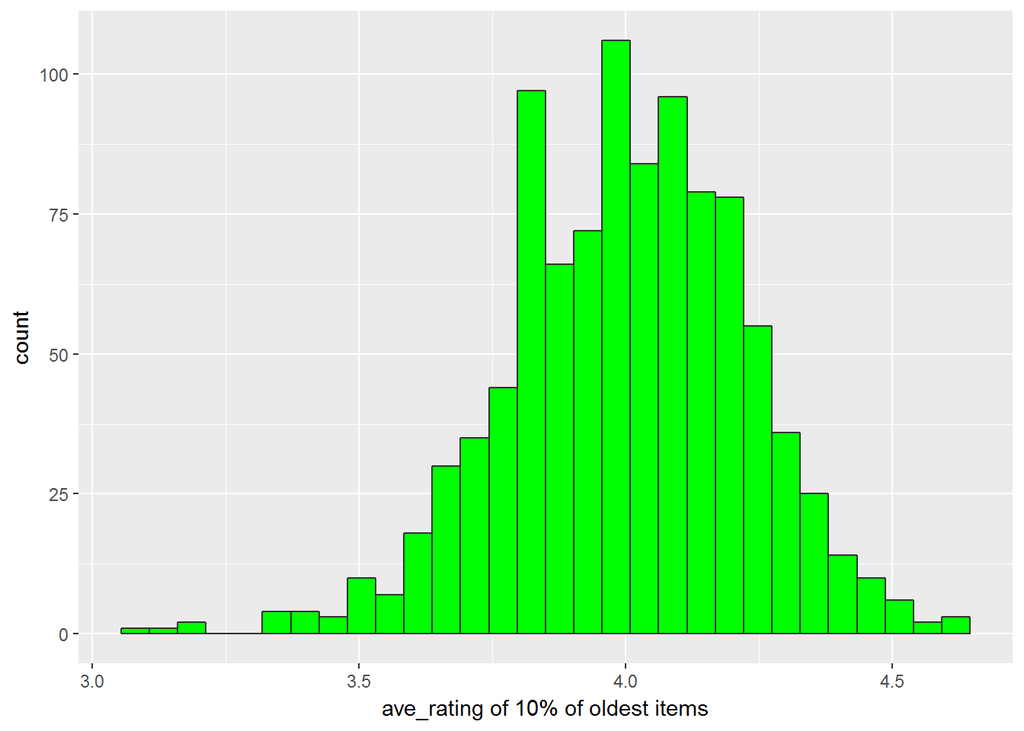

```r
books %>%
  filter(original_publication_year<
                 quantile(original_publication_year,probs=.1,na.rm=T) )%>%
  ggplot(aes(average_rating)) + geom_histogram(fill = "green", color = "grey20")+
  xlab("ave_rating of 10% of oldest items")
```

```r
books %>%
  filter(original_publication_year>
                 quantile(original_publication_year,probs=.9,na.rm=T) )%>%
    select(average_rating)%>%
  summary()
```

```
##  average_rating
##  Min.   :2.840
##  1st Qu.:3.790
##  Median :4.010
##  Mean   :3.986
##  3rd Qu.:4.190
##  Max.   :4.770
```

```r
books %>%
  filter(original_publication_year<
                 quantile(original_publication_year,probs=.1,na.rm=T) )%>%
    select(average_rating)%>%
  summary()
```

```
##  average_rating
##  Min.   :3.09
##  1st Qu.:3.85
##  Median :4.00
##  Mean   :4.00
##  3rd Qu.:4.15
##  Max.   :4.63
```

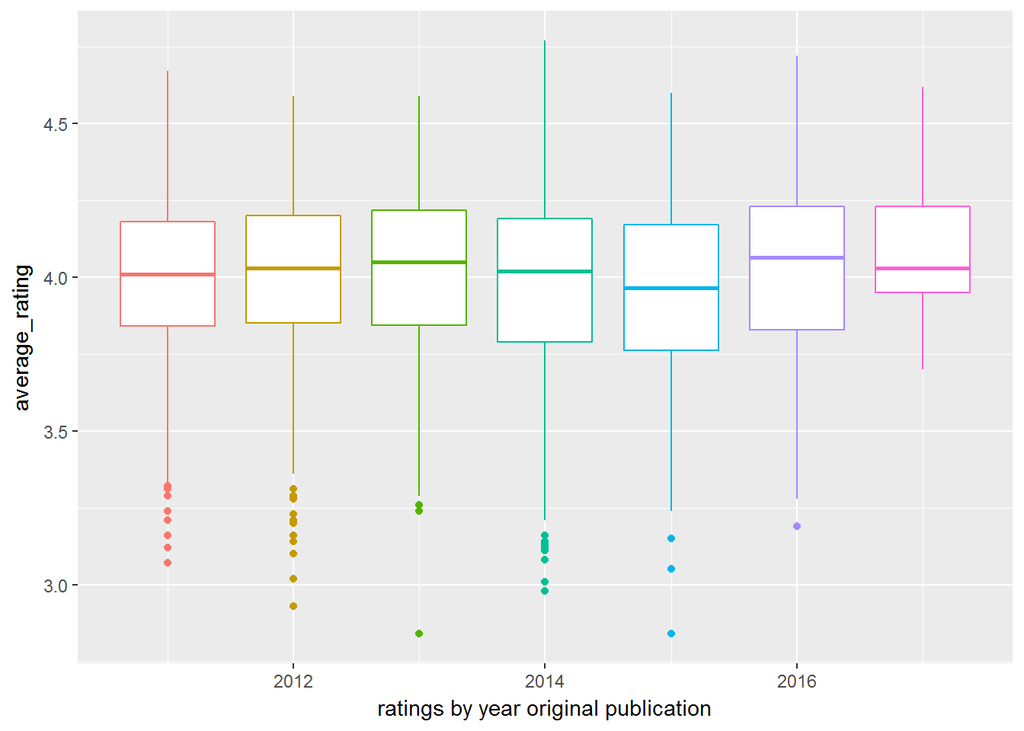

```r
#books <- books %>%
#  mutate(title_cleaned = str_trim(str_extract(title, '([0-9a-zA-Z]| |\'|,|\\.|\\*)*')),
#         title_length = str_count(title_cleaned, " ") + 1)
#tmp <- books %>%
#  group_by(title_length) %>%
#  summarize(n = n()) %>%
#  mutate(ind = rank(title_length))
books %>%
  filter(original_publication_year> quantile(original_publication_year,probs=.7,na.rm=T) )%>%
  ggplot(aes((original_publication_year), average_rating, color=factor(original_publication_year), group=original_publication_year)) +
  geom_boxplot() + guides(color = FALSE) + labs(x = "ratings by year original publication")
```

A slight upvote for 2016. Data has only a few points for 2017. Then a downwave at 15 & 14. Idk why. Anyway this type of attack is probably fine because it helps the industry by making it more lucrative for investors. However, shilling, promote, attacks and nuke bury anchor demote attacks are a problem. Even basic user-user similarity will not easily fall for these because user will likely vote down a promotion attack and resposible shill accounts will become ignored. I think an example of this is overhypedness of Dan Brown’s the Da Vinci Code caused a backlash. At least the shills would need to rate well most of the time so a few shill promoted items would get in, but only a few. Even if most of the dataset was composed of shills, they would compete to provide good ratings so that their ratings influence the algorithm more. Bury attacks against popular items create very high spread in ratings. Twighlight illustrates this even if the ratings are honest opinions. Bury attacks against unknown items could only be countered by someone with good reputation promoting or defending these items. If user of recommender knew of one buried item and voted it highly that would just counter the possibly very few shills attacking this specific item. Users need to continuosly rate in reaction to what they are recommended as well as at least a few rare items they liked. Plenty of papers on attack resistant algorithms means some will be added.

An example of an attack on Item-item recs: https://www.youtube.com/watch?v=RZAUBBmhKFU.

#### Series of items

The data contains information in the `title` column about whether a certain item is part of a series (e.g. the Lord of the Rings trilogy).

```r
books %>%
  filter(str_detect(str_to_lower(title), '\\(the lord of the rings')) %>%
  select(book_id, title, average_rating) %>%
  datatable(class="nowrap hover row-border", options = list(dom = 't',scrollX = TRUE, autoWidth = TRUE))
```

|  | book_id | title | average_rating |
| --- | --- | --- | --- |
| 1 | 19 | The Fellowship of the Ring (The Lord of the Rings, #1) | 4.34 |
| 2 | 155 | The Two Towers (The Lord of the Rings, #2) | 4.42 |
| 3 | 161 | The Return of the King (The Lord of the Rings, #3) | 4.51 |
| 4 | 189 | The Lord of the Rings (The Lord of the Rings, #1-3) | 4.47 |

Given this, we can extract the series from the `title`, as it is always given in parantheses. We can then calculate features like the number of volumes in a series, and so forth.

Below, I examine whether items which are part of a larger series receive a higher rating. In fact the more volumes are in a series, the higher the average rating is.

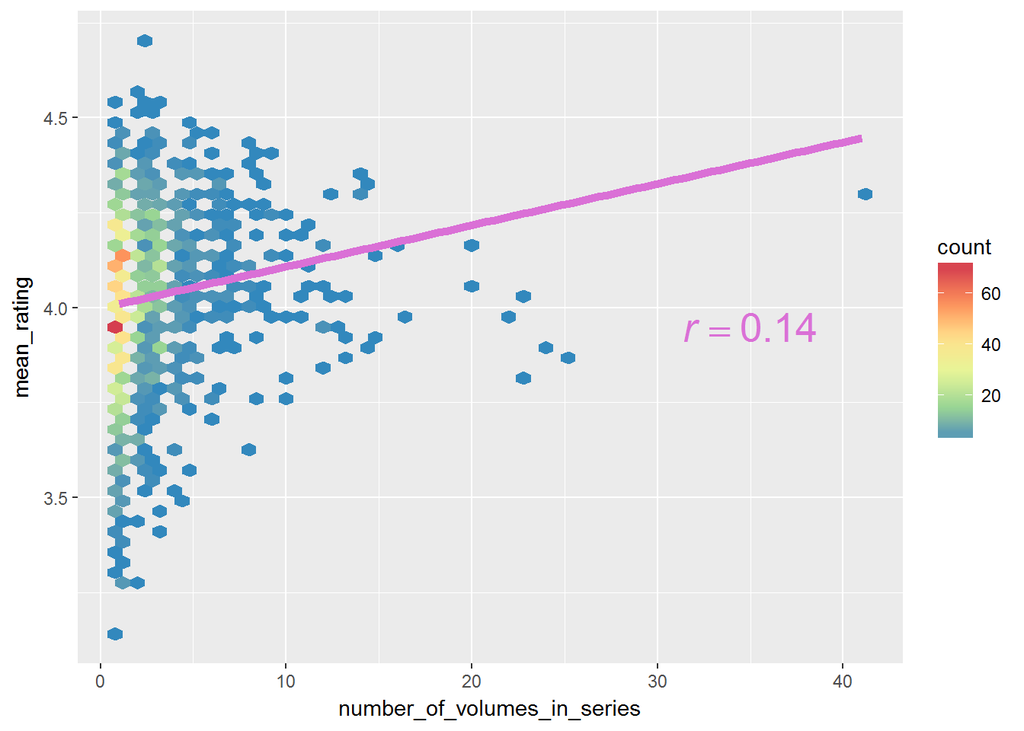

```r
books <- books %>%
  mutate(series = str_extract(title, "\\(.*\\)"),
         series_number = as.numeric(str_sub(str_extract(series, ', #[0-9]+\\)$'),4,-2)),
         series_name = str_sub(str_extract(series, '\\(.*,'),2,-2))

tmp <- books %>%
  filter(!is.na(series_name) & !is.na(series_number)) %>%
  group_by(series_name) %>%
  summarise(number_of_volumes_in_series = n(), mean_rating = mean(average_rating))

tmp %>%
  ggplot(aes(number_of_volumes_in_series, mean_rating)) + stat_bin_hex(bins = 50) + scale_fill_distiller(palette = "Spectral") +
  stat_smooth(method = "lm", se = FALSE, size = 2, color = "orchid") +
  annotate("text", x = 35, y = 3.95, label = get_cor(data.frame(x = tmp$mean_rating,  y = tmp$number_of_volumes_in_series)), color = "orchid", size = 7, parse = TRUE)
```

#### Is the sequel better than the original?

We can also see that within a series, in fact the sequel is rated slightly better than the original.

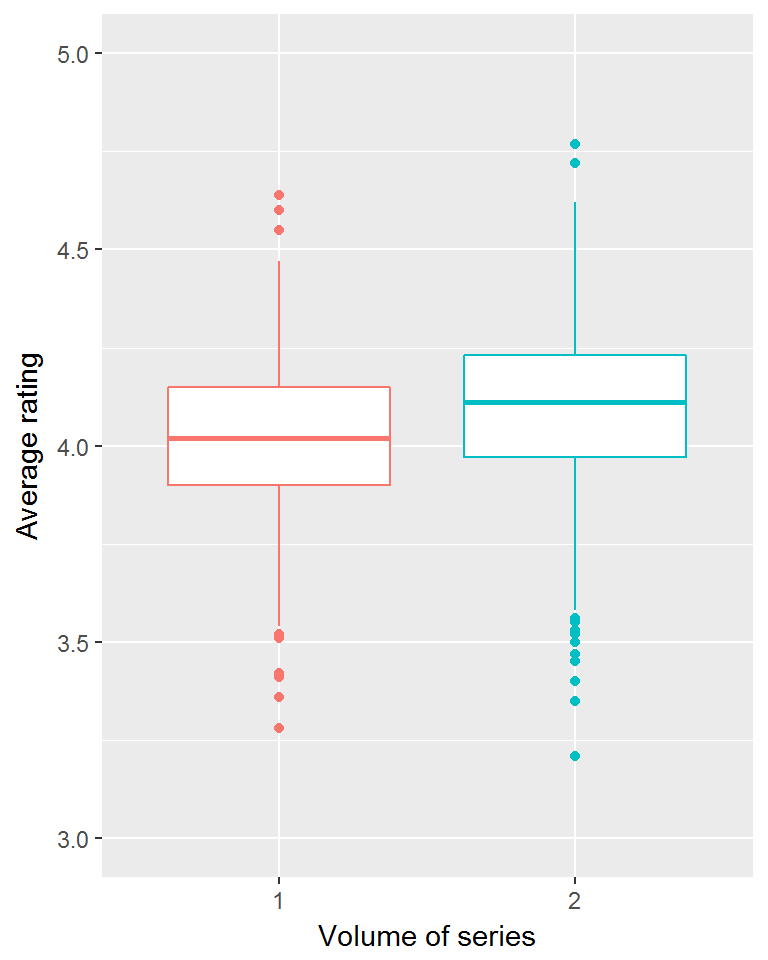

```r
books %>%
  filter(!is.na(series_name) & !is.na(series_number) & series_number %in% c(1,2)) %>%
  group_by(series_name, series_number) %>%
  summarise(m = mean(average_rating)) %>%
  ungroup() %>%
  group_by(series_name) %>%
  mutate(n = n()) %>%
  filter(n == 2) %>%
  ggplot(aes(factor(series_number), m, color = factor(series_number))) +
  geom_boxplot() + coord_cartesian(ylim = c(3,5)) + guides(color = FALSE) + labs(x = "Volume of series", y = "Average rating")
```

#### How long should a title be?

If you are an author, one of the most important choices is the title of a item. Of course the content of the title is important. However, it might also matter how long the title is. Below I therefore plot the average rating as a function of the length of the title (in words). We can see that there is in fact some variation in average rating depending on title length. Titles with 3 or 7 words seem to have slightly higher ratings.

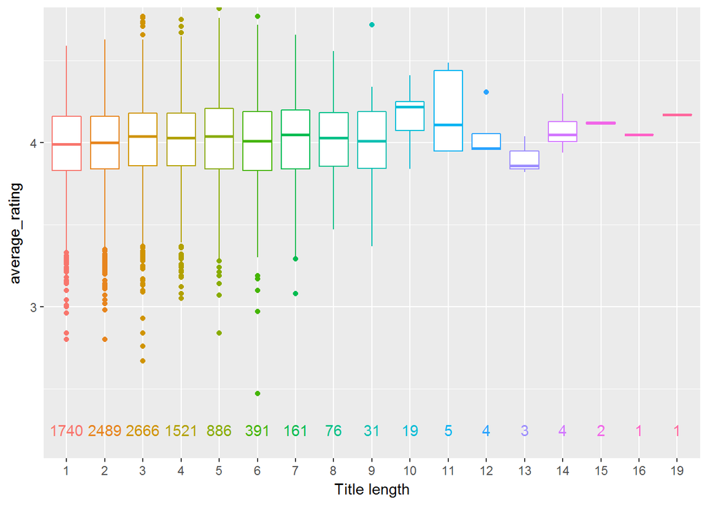

```r
books <- books %>%
  mutate(title_cleaned = str_trim(str_extract(title, '([0-9a-zA-Z]| |\'|,|\\.|\\*)*')),
         title_length = str_count(title_cleaned, " ") + 1)

tmp <- books %>%
  group_by(title_length) %>%
  summarize(n = n()) %>%
  mutate(ind = rank(title_length))

books %>%
  ggplot(aes(factor(title_length), average_rating, color=factor(title_length), group=title_length)) +
  geom_boxplot() + guides(color = FALSE) + labs(x = "Title length") + coord_cartesian(ylim = c(2.2,4.7)) + geom_text(aes(x = ind,y = 2.25,label = n), data = tmp)
```

#### Does having a subtitle improve the item’s rating?

We see that items that have a subtitle get rated slightly higher than items without a subtitle.

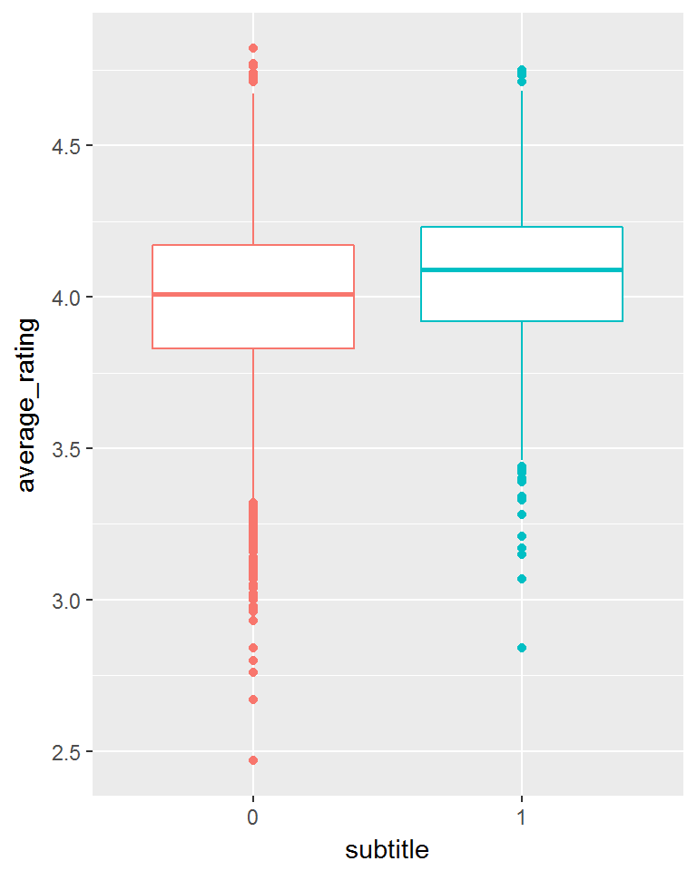

```r
books <- books %>%
  mutate(subtitle = str_detect(books$title, ':') * 1, subtitle = factor(subtitle))

books %>%
  ggplot(aes(subtitle, average_rating, group = subtitle, color = subtitle)) +
  geom_boxplot() + guides(color = FALSE)
```

#### Does the number of authors matter?

We all know the saying: “too many cooks spoil the broth.” Is this also true for items? Looking at the plot below it seems to be exactly the opposite: The more authors a item has the higher is its average rating.

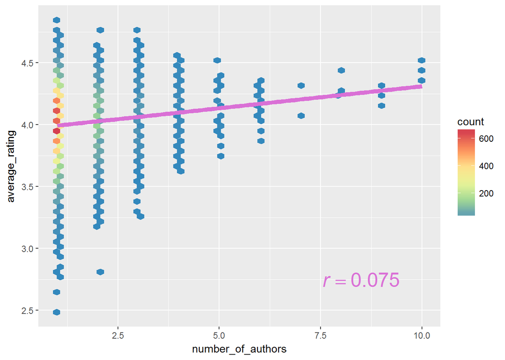

```r
books <- books %>%
  group_by(book_id) %>%
  mutate(number_of_authors = length(str_split(authors, ",")[[1]]))

books %>% filter(number_of_authors <= 10) %>%
  ggplot(aes(number_of_authors, average_rating)) + stat_bin_hex(bins = 50) + scale_fill_distiller(palette = "Spectral") +
  stat_smooth(method = "lm", size = 2, color = "orchid", se = FALSE) +
  annotate("text", x = 8.5, y = 2.75, label = get_cor(data.frame(x = books$number_of_authors, y = books$average_rating)), color = "orchid", size = 7, parse = TRUE)
```

### Summary - Part I

We identified some interesting aspects of this item datasets. In summary, observed effects on item rating are rather small, suggesting that item rating is mainly driven by other aspects, hopefully including the quality of the item itself. In part II we are going to look at collaborative filtering and eventually build a recommender app in shiny in part III.